# Economia Naranja

EOCode

7/5/2020

Para ejecutar este notebook se requiere de:

```r
library(rmarkdown)
library(knitr)
library(ggplot2)
library(dplyr)
library(RColorBrewer)
```

Importamos el Dataset

```r
orange = read.csv("data.csv")
data(orange)
summary(orange)
```

```
##    Country              GDP.PC       GDP.US.bill         GDP.Growth..
##  Length:17          Min.   : 5600   Min.   :     13.7   Min.   :0.800
##  Class :character   1st Qu.: 8300   1st Qu.:     37.1   1st Qu.:2.000
##  Mode  :character   Median :13300   Median :     75.7   Median :2.800
##                     Mean   :14053   Mean   : 188693.0   Mean   :2.959
##                     3rd Qu.:19900   3rd Qu.:    309.2   3rd Qu.:4.200
##                     Max.   :25400   Max.   :2055000.0   Max.   :5.400
##
##  Services...GDP  Creat.Ind...GDP   Inflation       Unemployment
##  Min.   :50.00   Min.   :1.000   Min.   : 0.400   Min.   : 2.300
##  1st Qu.:56.90   1st Qu.:2.000   1st Qu.: 1.600   1st Qu.: 5.500
##  Median :62.20   Median :2.600   Median : 3.400   Median : 6.700
##  Mean   :62.64   Mean   :3.291   Mean   : 4.365   Mean   : 6.794
##  3rd Qu.:64.90   3rd Qu.:3.950   3rd Qu.: 4.300   3rd Qu.: 8.100
##  Max.   :82.00   Max.   :7.400   Max.   :25.700   Max.   :11.800
##                  NA's   :6
##  X..pop.below.poverty.line Internet.penetration...population   Median.age
##  Min.   : 4.20             Min.   :38.20                     Min.   :22.10
##  1st Qu.:21.70             1st Qu.:57.70                     1st Qu.:25.70
##  Median :25.70             Median :69.70                     Median :28.20
##  Mean   :27.65             Mean   :68.42                     Mean   :28.28
##  3rd Qu.:32.70             3rd Qu.:79.90                     3rd Qu.:31.30
##  Max.   :59.30             Max.   :93.10                     Max.   :35.00
##
##   X..pop.25.54   Education.invest...GDP
##  Min.   :34.12   Min.   :2.800
##  1st Qu.:39.23   1st Qu.:4.400
##  Median :40.19   Median :5.000
##  Mean   :39.88   Mean   :5.082
##  3rd Qu.:41.08   3rd Qu.:5.900
##  Max.   :44.03   Max.   :7.400
##
```

¿Cuál es el máximo PIB Percápita en los paises de latam (GDP.PC )?

```r
max(orange$GDP.PC)
```

```
## [1] 25400
```

¿Qué país o países aportan con su economía naranja más del 5% al PIB y además tienen una tasa de desempleo menor al 5%?

```r
library(dplyr)
TopCountries = filter(orange, Unemployment < 5 & Creat.Ind...GDP > 5)
TopCountries = subset(TopCountries, select = c("Country","Unemployment","Creat.Ind...GDP"))
TopCountries
```

```
##   Country Unemployment Creat.Ind...GDP
## 1  Mexico          3.6             7.4
```

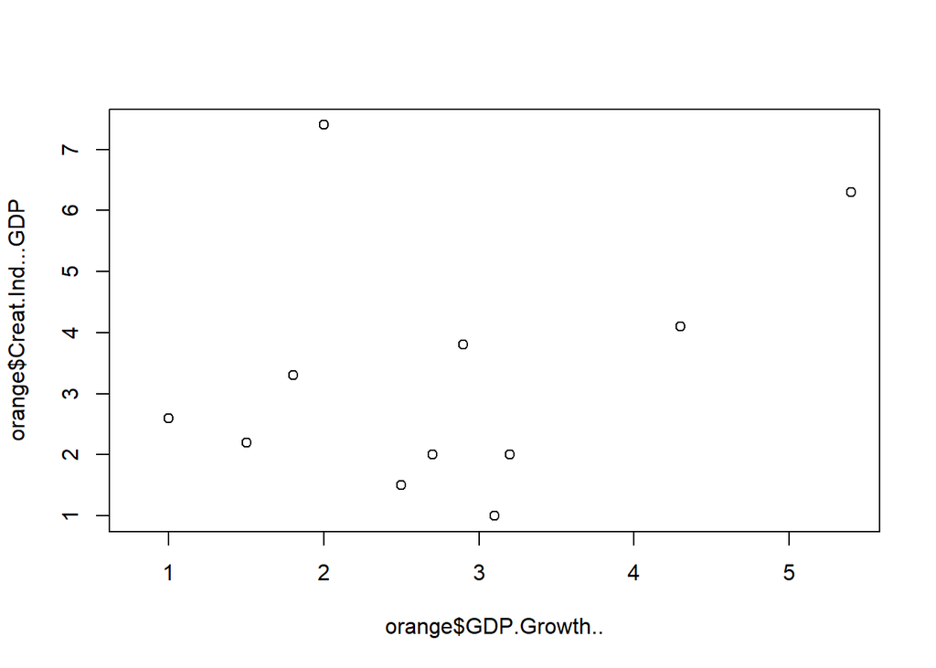

```r
plot(orange$Creat.Ind...GDP~orange$GDP.Growth..)
```

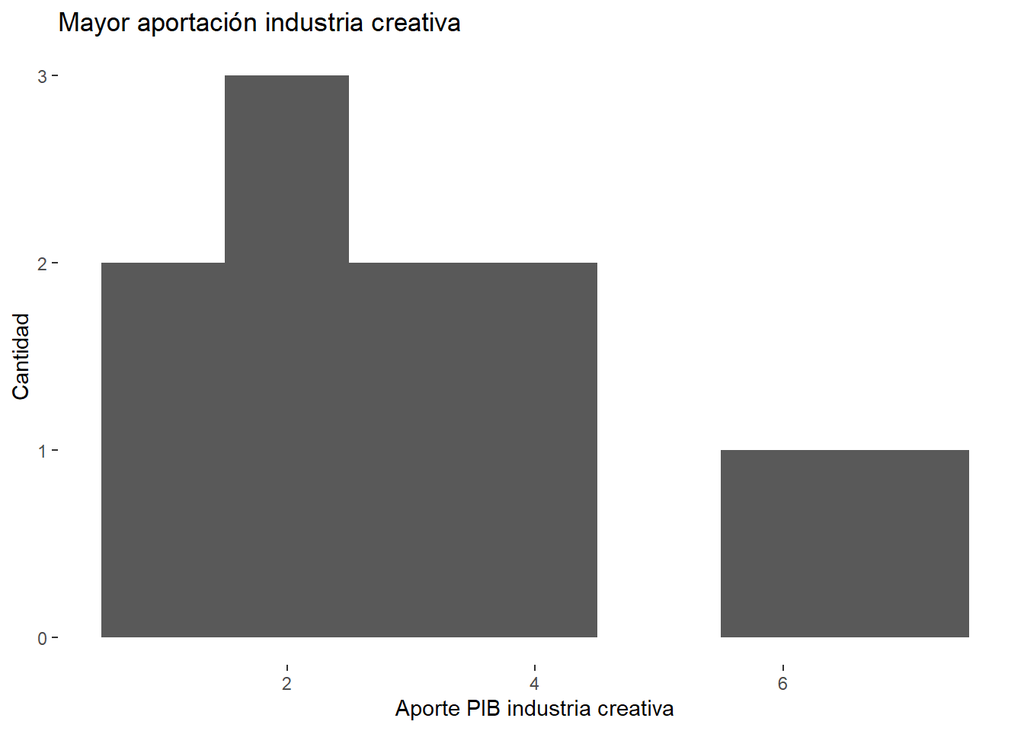

```r
ggplot(orange, aes(x=Creat.Ind...GDP))+
  geom_histogram(binwidth = 1)+
  labs(x="Aporte PIB industria creativa",
       y="Cantidad",
       title="Mayor aportación industria creativa")+
  theme(legend.position = "none")+
  theme(panel.background = element_blank(), panel.grid.major = element_blank(), panel.grid.minor = element_blank())
```

```r
mean_economy = mean(orange$GDP.PC)
mean_economy
```

```
## [1] 14052.94
```

```r
orange = orange %>%
  mutate(Strong_economy = ifelse(GDP.PC < mean_economy,
                                 "Por debajo del promedio pib per capita",
                                 "Sobre arriba promedio pib per capita"))
```

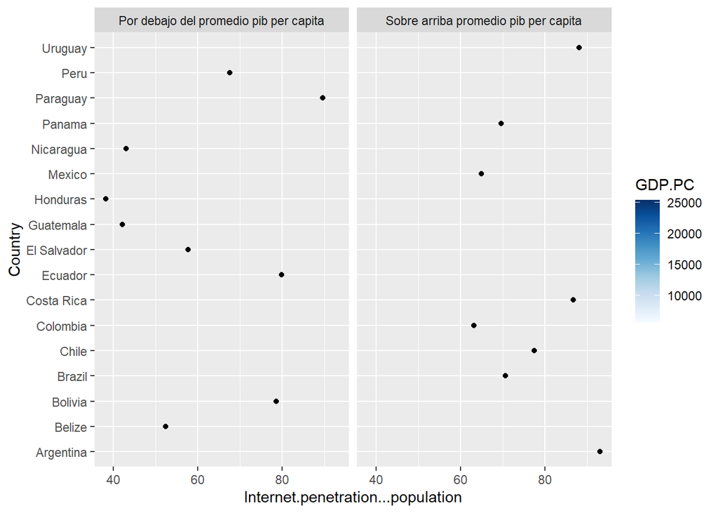

```r
myColors = brewer.pal(9,"Blues")
ggplot(orange, aes(x=Internet.penetration...population, y=Country, fill=GDP.PC))+
  geom_point()+
  facet_wrap(~Strong_economy)+
  scale_fill_gradientn(colors=myColors)
```

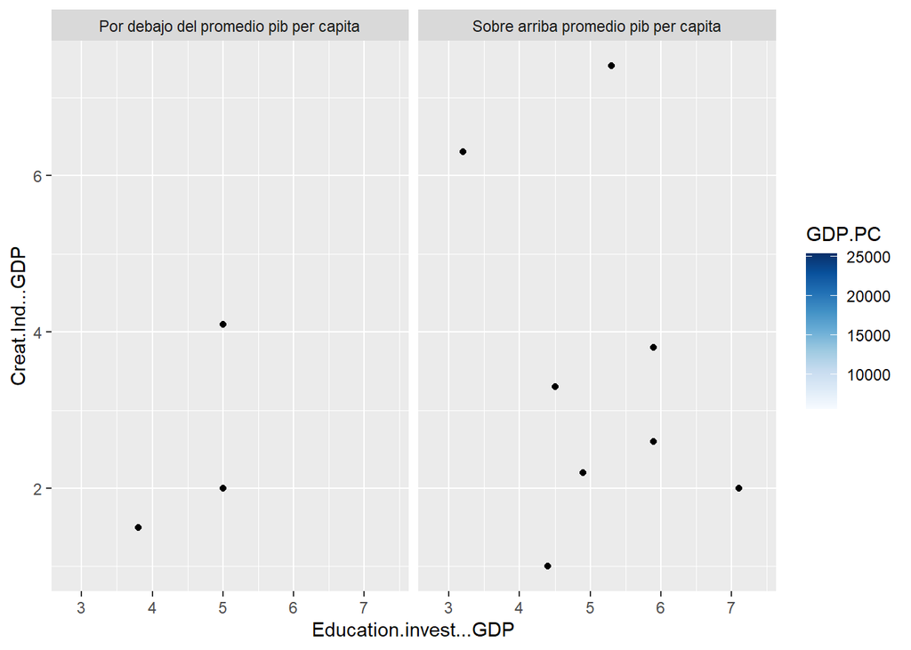

```r
myColors = brewer.pal(9,"Blues")
ggplot(orange, aes(x=Education.invest...GDP, y=Creat.Ind...GDP, fill=GDP.PC))+
  geom_point()+
  facet_wrap(~Strong_economy)+
  scale_fill_gradientn(colors=myColors)
```

En el dataset orangeec, al usar pairs, vemos que en la relación entre el aporte de los servicios al pib (Services…GDP) y el PIB per cápita (GDP.PC), los puntos:

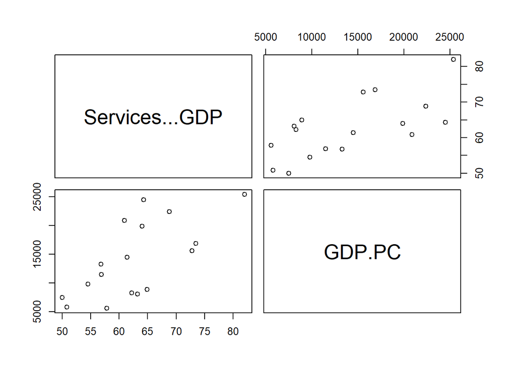

```r
a = subset(orange, select=c("Services...GDP","GDP.PC"))
pairs(a[,1:2])
```

```r
cor(a[,1:2])
```

```
##                Services...GDP    GDP.PC
## Services...GDP      1.0000000 0.6733943
## GDP.PC              0.6733943 1.0000000
```

En el dataset orangeec, la correlación entre el crecimiento del pib de un pais (GDP.Growth…) y el aporte de la economía naranja al pib del país (Creat.Ind…GDP) es de:

```r
b = subset(orange, select=c("GDP.Growth..","Creat.Ind...GDP"), na.rm = TRUE)
b <- b[!is.na(b$Creat.Ind...GDP),]
cor(b[,1:2])
```

```
##                 GDP.Growth.. Creat.Ind...GDP
## GDP.Growth..       1.0000000       0.3124484
## Creat.Ind...GDP    0.3124484       1.0000000
```

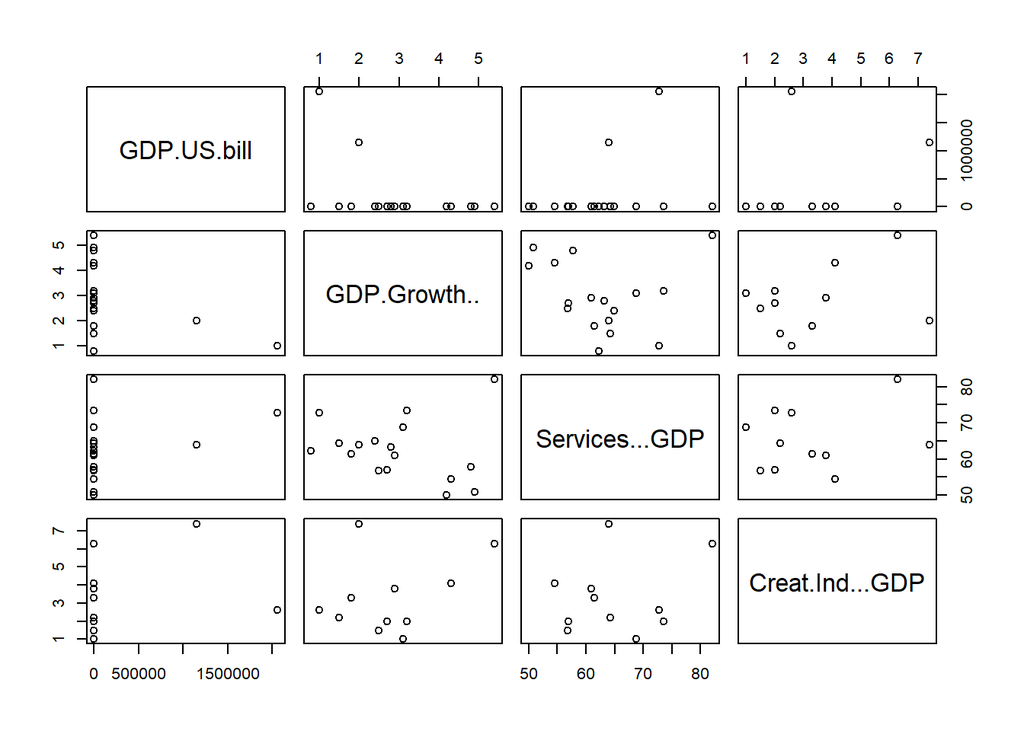

```r
pairs(orange[,3:6])
```

Al hacer un scatter plot con el dataset orangeec usando facet_wrap cruzando dos variables (numéricas) , al escribir al final facet_wrap(~Crecimiento_GDP), lo que veremos será:

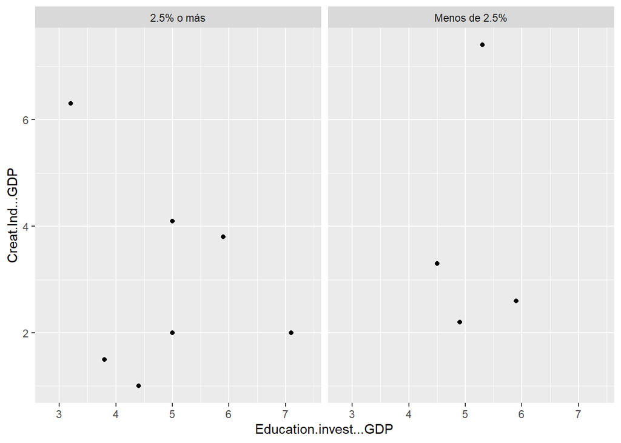

```r
orange = orange %>%
  mutate(Crecimiento_GDP = ifelse(GDP.Growth.. >= 2.5,
                                  "2.5% o más",
                                  "Menos de 2.5%"))
ggplot(orange, aes(x=Education.invest...GDP, y=Creat.Ind...GDP))+
  geom_point()+
  facet_wrap(~Crecimiento_GDP)
```

Parece que hay correlación entre aporte de economía naranja al PIB y la tasa de desempleo

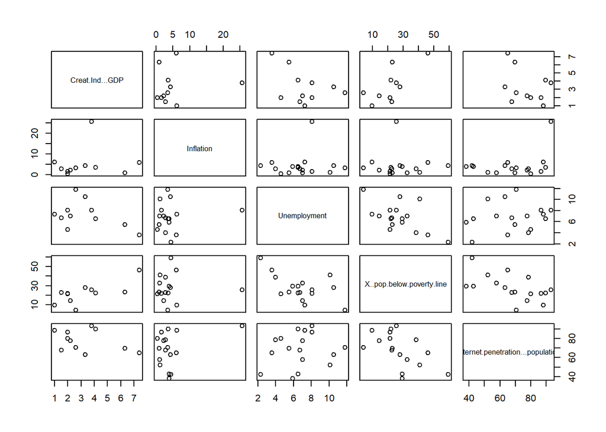

```r
pairs(orange[,6:10])
```

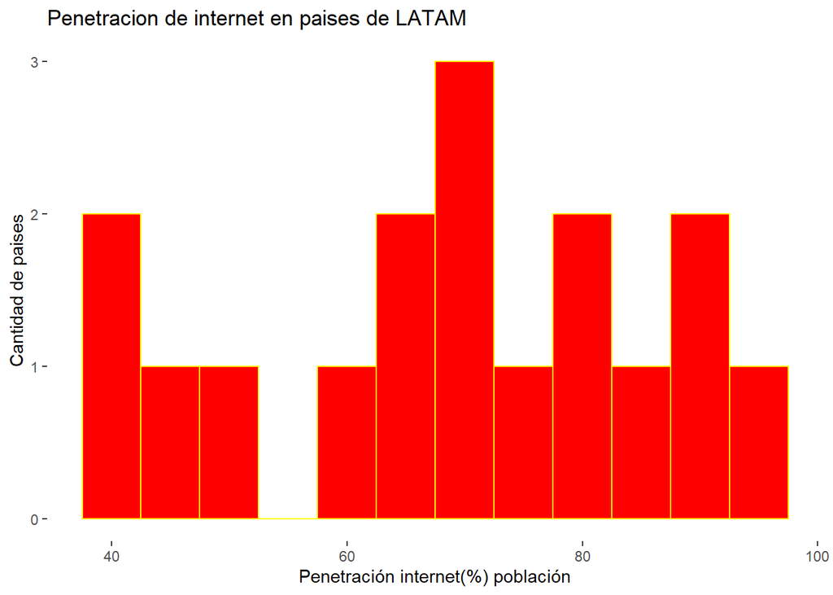

```r
ggplot()+geom_histogram(data=orange,
                        aes(x=Internet.penetration...population),fill='red',color='yellow',
                        binwidth=5)+
  labs(x="Penetración internet(%) población", y="Cantidad de paises",
       title="Penetracion de internet en paises de LATAM")+
  theme(legend.position = 'none')+
  theme(panel.background = element_blank(),panel.grid.major = element_blank(),
        panel.grid.minor = element_blank())
```

```r
economy <- mean(orange$GDP.PC)
economy
```

```
## [1] 14052.94
```

```r
orange <-orange %>%
  mutate(Strong_economy = ifelse(GDP.PC < economy,
                                 "Por debajo promedio pib per capita",
                                 "Sobre-Arriba promedio pib per capita"))
```

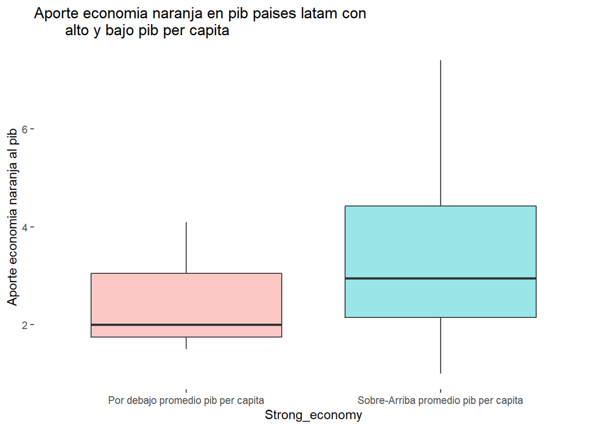

```r
ggplot(orange, aes(x=Strong_economy, y=Creat.Ind...GDP,
                    fill=Strong_economy))+
  geom_boxplot(alpha=0.4)+
  labs(c="Tipo de pais", y="Aporte economia naranja al pib",
       title="Aporte economia naranja en pib paises latam con
       alto y bajo pib per capita")+
  theme(legend.position = "none")+
  theme(panel.background = element_blank(),
        panel.grid.major = element_blank(),
        panel.grid.minor = element_blank())
```

El boxplot indica que los países sobre el promedio en PIB per cápita, tienen una dispersión mucho más alta en cueanto a los aportes de la economía naranja del paí. Ojo confirmar con desviación estándar.